# NDVI Trend Analysis Paulilatino

2023-09-30 16:25:06

Questo documento riassume il procedimento utilizzato per estrarre i vLalori dell’NDVI per ogni pixel all’interno dei poligoni delle chiome per almeno i 2/3 della propria area. e analizzare il trend dell’NDVI per ogni chioma delineata di olivastro.

```r
library(sf)
library(dplyr)
library(raster)
```

```r
# Carica i file necessari all'elaborazione
crowns0 <- st_read("G:/Altri computer/Il_mio_computer/DOTTORATO/PROGETTI/OLIVASTRO_PAULILATINO/REGRESSIONE/VETTORIALI/CHIOME_ANALISI_NDVI_2.shp")
```

```r
# Proietta le feature "crowns"
crowns <- st_transform(crowns0, crs = "+proj=utm +zone=32 +datum=WGS84 +units=m +no_defs")

# Raggruppa per area aggiungi l'ID
crowns <- crowns %>%
  group_by(AREA) %>%
  mutate(ID = row_number()) %>%
  ungroup() %>%
  mutate(CODICE_UNIVOCO = paste(AREA, ID, sep = "_"))

# Salva l'oggetto sf nel formato Shapefile
st_write(crowns, "G:/Altri computer/Il_mio_computer/DOTTORATO/PROGETTI/OLIVASTRO_PAULILATINO/REGRESSIONE/VETTORIALI/CHIOME_ANALISI_NDVI_2_correct.shp", append = FALSE)

# Dividi l'oggetto crowns per area
crowns_list <- split(crowns, crowns$AREA)

# Salva un file shp per ogni area
for (i in seq_along(crowns_list)) {
  area_name <- names(crowns_list)[i]
  file_name <- paste0("G:/Altri computer/Il_mio_computer/DOTTORATO/PROGETTI/OLIVASTRO_PAULILATINO/REGRESSIONE/VETTORIALI/crowns_areas/", area_name, ".shp")
  st_write(crowns_list[[i]], file_name, append = FALSE)
}
```

Questo è la struttura e la composizione del file crowns.

```
## Simple feature collection with 1390 features and 3 fields
## Geometry type: POLYGON
## Dimension:     XY
## Bounding box:  xmin: 473672.7 ymin: 4431004 xmax: 483022.4 ymax: 4437127
## Projected CRS: +proj=utm +zone=32 +datum=WGS84 +units=m +no_defs
## First 10 features:
##          AREA ID       CODICE_                       geometry
## 1  PONTE_EZZU  1  PONTE_EZZU_1 POLYGON ((481583.1 4433925,...
## 2  PONTE_EZZU  2  PONTE_EZZU_2 POLYGON ((481596.7 4433921,...
## 3  PONTE_EZZU  3  PONTE_EZZU_3 POLYGON ((481576.5 4433933,...
## 4  PONTE_EZZU  4  PONTE_EZZU_4 POLYGON ((481598.5 4433912,...
## 5  PONTE_EZZU  5  PONTE_EZZU_5 POLYGON ((481589.2 4433892,...
## 6  PONTE_EZZU  6  PONTE_EZZU_6 POLYGON ((481576.4 4433904,...
## 7  PONTE_EZZU  7  PONTE_EZZU_7 POLYGON ((481608.6 4433908,...
## 8  PONTE_EZZU  8  PONTE_EZZU_8 POLYGON ((481589.2 4433900,...
## 9  PONTE_EZZU  9  PONTE_EZZU_9 POLYGON ((481615.4 4433892,...
## 10 PONTE_EZZU 10 PONTE_EZZU_10 POLYGON ((481614.7 4433883,...
```

```r
# Ripulisci l'enviroment di R
rm(list=ls())
```

In questa sezione viene ritagliato il raster multilayer ndvi sulla base dell’estensione dei poligoni situati nelle aree:

```r
#  Carica il file raster multilayer
ndvi <- terra::rast("G:/Altri computer/Il_mio_computer/DOTTORATO/PROGETTI/OLIVASTRO_PAULILATINO/MODELLO/RASTER/ndvi_merged.tif")

# Carica il file SHP dei poligoni
crowns <- st_read("G:/Altri computer/Il_mio_computer/DOTTORATO/PROGETTI/OLIVASTRO_PAULILATINO/REGRESSIONE/VETTORIALI/CHIOME_ANALISI_NDVI_2_correct.shp")

# Imposta la cartella di output
output_folder <- "G:/Altri computer/Il_mio_computer/DOTTORATO/PROGETTI/OLIVASTRO_PAULILATINO/REGRESSIONE/RASTER/NDVI_CLIPPED"
```

```r
# Trova i nomi unici delle aree
unique_aree <- unique(crowns$AREA)

# Itera attraverso le aree
for (area_nome in unique_aree) {
  area_poligoni <- crowns[crowns$AREA == area_nome, ]

  # Crea un'estensione totale per i poligoni dell'area
  area_extent <- st_bbox(area_poligoni)

  # Ritaglia il raster con l'estensione totale dell'area
  raster_ritagliato <- crop(ndvi, area_extent)

  # Crea il percorso completo per il salvataggio
  nome_file <- file.path(output_folder, paste(area_nome,"_ndvi", ".tif", sep = ""))

  # Salva il raster ritagliato con il nome dell'area
  terra::writeRaster(raster_ritagliato, nome_file, overwrite = TRUE)

  cat("Raster ritagliato e salvato per l'area:", area_nome, "\n")
}

cat("Processo completato.")
```

```r
# Ripulisci l'enviroment di R
rm(list=ls())
```

```r
# Load the required libraries
library(sf)
library(terra)
library(readr)
library(dplyr)
```

In questa sezione vado a rinominare i layer di tutti i file raster di ogni area con le date delle immagini satellitari.

```r
raster_folder0  <- "G:/Altri computer/Il_mio_computer/DOTTORATO/PROGETTI/OLIVASTRO_PAULILATINO/REGRESSIONE/RASTER/NDVI_CLIPPED"

# List files in the folders
raster_files0 <- list.files(raster_folder0, pattern = ".tif$", full.names = TRUE)

output_folder0 <- "G:/Altri computer/Il_mio_computer/DOTTORATO/PROGETTI/OLIVASTRO_PAULILATINO/REGRESSIONE/RASTER/NDVI_CLIPPED_NEW"

date <- read_csv("G:/Altri computer/Il_mio_computer/DOTTORATO/PROGETTI/OLIVASTRO_PAULILATINO/REGRESSIONE/date.csv", col_names = TRUE)
```

```r
# Seleziono e creo un nuovo file con le date
dates <- unique(date$date)

# Estrai l'anno e il mese e crea il formato "YYYY-MM-DD"
year_month <- paste(substr(dates, 7, 10), substr(dates, 4, 5), sep = "-", substr(dates, 1, 2))

# Itera attraverso i file raster e rinomina i layer con le date
for (i in seq_along(raster_files0)) {
  raster_file <- terra::rast(raster_files0[i])
  names(raster_file) <- year_month
  new_filename <- file.path(output_folder0, paste0(basename(raster_files0[i])))
  writeRaster(raster_file, filename = new_filename, overwrite = TRUE)
}
```

```r
# Ripulisci l'enviroment di R
rm(list=ls())
```

In questa sezione vado ad estrarre i pixel che sono situati all’interno, per almeno il 2/3 della loro area, dei poligoni delle chiome. In nuovi file con i pixel estratti saranno in formato shp.

```r
# Set the path to the shapefile and raster file
shapefile_folder  <- "G:/Altri computer/Il_mio_computer/DOTTORATO/PROGETTI/OLIVASTRO_PAULILATINO/REGRESSIONE/VETTORIALI/crowns_areas"
raster_folder  <- "G:/Altri computer/Il_mio_computer/DOTTORATO/PROGETTI/OLIVASTRO_PAULILATINO/REGRESSIONE/RASTER/NDVI_CLIPPED_NEW"
output_folder <- "G:/Altri computer/Il_mio_computer/DOTTORATO/PROGETTI/OLIVASTRO_PAULILATINO/REGRESSIONE/VETTORIALI/NDVI_EXTRACTED"
```

```r
# List files in the folders
raster_files <- list.files(raster_folder, pattern = ".tif$", full.names = TRUE)
shapefile_files <- list.files(shapefile_folder, pattern = ".shp$", full.names = TRUE)
```

```r
# Iterate through files
for (i in 1:length(raster_files)) {
  shp0 <- vect(shapefile_files[i])
  rast <- terra::rast(raster_files[i])

  # Extract raster values
  ex <- terra::extract(rast, shp0, method = "simple", exact = TRUE, xy = TRUE, ID = FALSE)

  # Convert shp from spatvector to sf object
  shp <- st_as_sf(shp0, crs = 32632)

  # If you want to convert the area to another unit, you can use the st_transform function
  shp$estensione <- st_area(st_transform(shp, crs = 32632), square = TRUE) # Change new_crs to the desired coordinate system

  # Filter polygons with at least 2/3 area coverage
  ex_filtered <- ex[ex$fraction >= (2/3),]

  # Create an sf object from the filtered data
  ex_sf <- st_as_sf(ex_filtered, coords = c("x", "y"))

  # Assign WGS 84 CRS to your sf object
  ex_sf <- st_set_crs(ex_sf, 32632)

  # Remove the fraction column (no longer needed now)
  ex_sf$fraction <- NULL

  # Remove duplicate rows based on all columns
  ex_sf2 <- distinct(ex_sf)

  # Assign the CRS of ex_sf to polygons
  polygons <- st_as_sf(shp, st_crs(ex_sf2))

  # Perform spatial join based on the position of ex_sf and polygons
  sf_join <- st_join(ex_sf2, polygons)

  # Calculate square side length (3 meters)
  side_length <- 3

  # Create squares using st_buffer
  quadrat_sf <- st_buffer(sf_join, side_length / 2, endCapStyle = "SQUARE")

  # Set CRS (EPSG:32632)
  quadrat_sf <- st_set_crs(quadrat_sf, 32632)

  # Elimina la colonna estensione
  quadrat_sf$estensione <- NULL

  # Rename columns to remove the "X" prefix
  colnames(quadrat_sf) <- gsub("^X", "", colnames(quadrat_sf))

  # Generate output filename based on the shapefile name
  area_name <- tools::file_path_sans_ext(basename(shapefile_files[i]))
  output_filename <- file.path(output_folder, paste0(area_name, ".shp"))

  # Write output shapefile
  st_write(quadrat_sf, output_filename, driver = "ESRI Shapefile", append = FALSE)
}
```

```r
# Ripulisci l'enviroment di R
rm(list=ls())
```

In questa sezione si preparano i file shp dei pixel estratti per ogni poligono della chioma e area alla sucessive elaborazioni. In particolare, dopo aver caricato tutti i file come oggetti sf, si estraggono le date dal file e si rinominano tutte le colonne. Questo è necessario perchè i nomi delle colonne non hanno ancora un formato compatibile con le date. Si trasforma in fattoriale la colonna `AREA`. Si ripulisce il dataset dalle colonne non più necessarie.

```r
library(sf)
library(dplyr)
library(tidyr)
```

```r
INPUT_folder <- "G:/Altri computer/Il_mio_computer/DOTTORATO/PROGETTI/OLIVASTRO_PAULILATINO/REGRESSIONE/VETTORIALI/NDVI_EXTRACTED"

# Ottenere la lista dei file SHP nella cartella
INPUT_shp <- list.files(path = INPUT_folder, pattern = "\\.shp$", full.names = TRUE)

# Caricare tutti i file SHP in una lista di oggetti sf
shp_list <- lapply(INPUT_shp, st_read)

# Estrai la data e rinomina le colonne
for (i in seq_along(shp_list)) {
  col_names <- colnames(shp_list[[i]])
  col_names <- gsub("^X", "", col_names)
  date_cols <- grep("^\\d{4}\\.\\d{2}\\.\\d{2}$", col_names)

  # Rinomina le colonne con le date estratte
  colnames(shp_list[[i]])[date_cols] <- col_names[date_cols]

  # Aggiungi la colonna con il nome del file di origine
  shp_list[[i]]$file_name <- tools::file_path_sans_ext(basename(INPUT_shp[i]))

  # Trasforma la colonna 'area' in un fattore
  shp_list[[i]]$AREA <- as.factor(shp_list[[i]]$AREA)
}

# Rimuovi le  colonne non necessarie
cols_to_exclude <- c("ID", "file_name")

long_format_list <- lapply(shp_list, function(shp) {
  shp %>%
    dplyr::select(-one_of(cols_to_exclude)) %>%
    pivot_longer(
      cols = -c(geometry, CODICE_, AREA),  # Include anche la colonna "geometry"
      names_to = "date",
      values_to = "ndvi"
    ) %>%
mutate(date = as.Date(date, format = "%Y.%m.%d"))
})


# Modifica il nome della colonna CODICE in COD per ciascun oggetto sf nella lista
for (i in seq_along(long_format_list)) {
  long_format_list[[i]] <- long_format_list[[i]] %>%
    rename(COD = CODICE_)
}
```

Si crea un file unico contente tutti gli oggetti della lista e lo si salva in locale.

```r
shapefile_folder  <- "G:/Altri computer/Il_mio_computer/DOTTORATO/PROGETTI/OLIVASTRO_PAULILATINO/REGRESSIONE/VETTORIALI/crowns_areas"

# Unisci tutti gli oggetti sf nella lista in un unico oggetto sf
combined_long_format <- bind_rows(long_format_list)

# Specifica il percorso del file in cui desideri salvare il tuo oggetto sf combinato
output_file3 <- "G:/Altri computer/Il_mio_computer/DOTTORATO/PROGETTI/OLIVASTRO_PAULILATINO/REGRESSIONE/VETTORIALI/NDVI_VALUES/NDVI_VALUES.shp"

# Salva l'oggetto sf combinato nel file shapefile
st_write(combined_long_format, output_file3, append= FALSE)
```

```r
# Ripulisci l'enviroment di R
rm(list=ls())
```

In questa sezione si calcola l’NDVI medio per ogni data e area in modo da poter vedere successivamente la tendenza generale dei ogni singola area.

```r
library(ggplot2)
library(dplyr)
library(sf)
```

```r
NDVI_VALUES <- st_read("G:/Altri computer/Il_mio_computer/DOTTORATO/PROGETTI/OLIVASTRO_PAULILATINO/REGRESSIONE/VETTORIALI/NDVI_VALUES/NDVI_VALUES.shp")

# Calcola l'NDVI medio per ogni data e per ogni area
ndvi_avg_areas <- NDVI_VALUES %>%
  group_by(date, AREA) %>%
  summarise(mean_NDVI = mean(ndvi, na.rm = TRUE))

# Salva l'oggetto sf combinato nel file shapefile
st_write(ndvi_avg_areas, "G:/Altri computer/Il_mio_computer/DOTTORATO/PROGETTI/OLIVASTRO_PAULILATINO/REGRESSIONE/VETTORIALI/NDVI_VALUES/ndvi_avg_areas.shp", append= FALSE)
```

```r
# Ripulisci l'enviroment di R
rm(list=ls())
```

In questa sezione vediamo la tendenza generale dell’NDVI per ogni singola area.

In questo grafico è possibile visuallizzare graficamente la tendenza dell’NDVI medio per ogni area su cui è stata effettuata l’analisi. Le tendenze sono state calcolate attraverso la funzione geom_smooth() del pacchetto ggplot2. In particolare è stato utilizzato il metodo lm() *- Linear Model

```r
library(ggplot2)
library(sf)
library(dplyr)
library(ggpubr)
library(RColorBrewer)
```

```r
# Imposta l'opzione scipen su un valore elevato per eliminare la notazione esponenziale dei valori
options(scipen = 999)

# Carica il file dei valori dell'ndvi medio per ogni area
ndvi_avg <- st_read("G:/Altri computer/Il_mio_computer/DOTTORATO/PROGETTI/OLIVASTRO_PAULILATINO/REGRESSIONE/VETTORIALI/NDVI_VALUES/ndvi_avg_areas.shp")
```

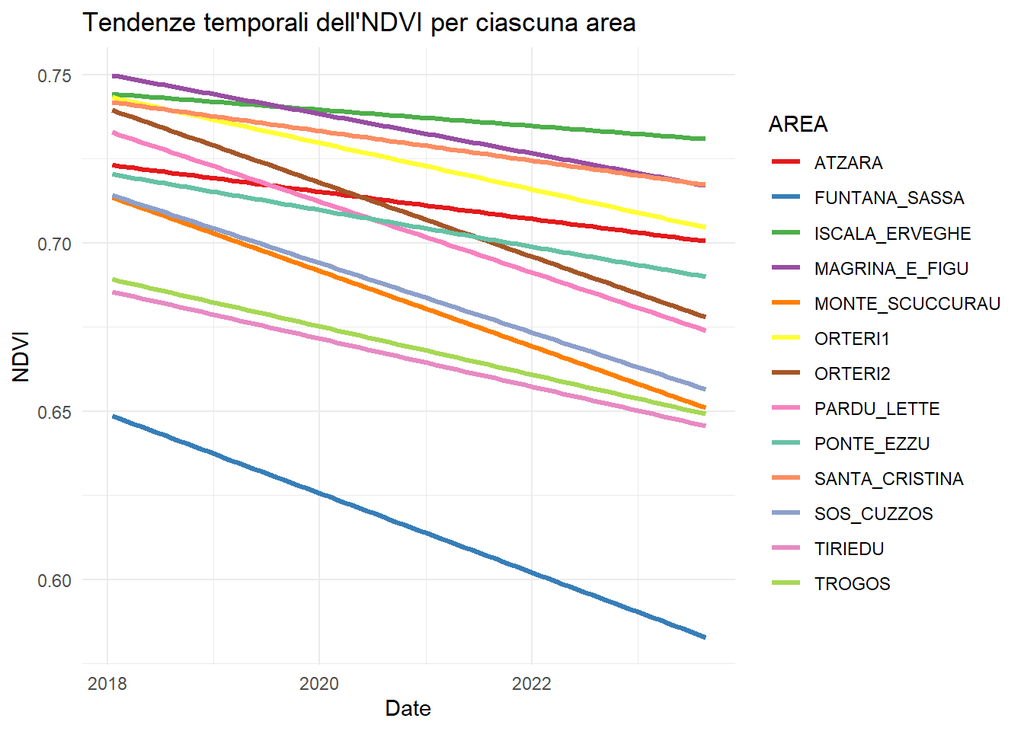

```r
# Creazione di una palette personalizzata
my_palette <- c(brewer.pal(8, "Set1"), brewer.pal(8, "Set2"), brewer.pal(8, "Set3"))
my_palette <- my_palette[1:13]  # Seleziona solo i primi 13 colori

# Utilizzo della palette personalizzata in ggplot
plot <- ggplot(ndvi_avg, aes(x = date, y = mean_NDVI, group = AREA, color = AREA)) +
  geom_smooth(method = "lm", se = FALSE, linewidth = 1.2) +
  scale_color_manual(values = my_palette) +
  labs(title = "Tendenze temporali dell'NDVI per ciascuna area",
       x = "Date",
       y = "NDVI") +
  theme_minimal()

plot
```

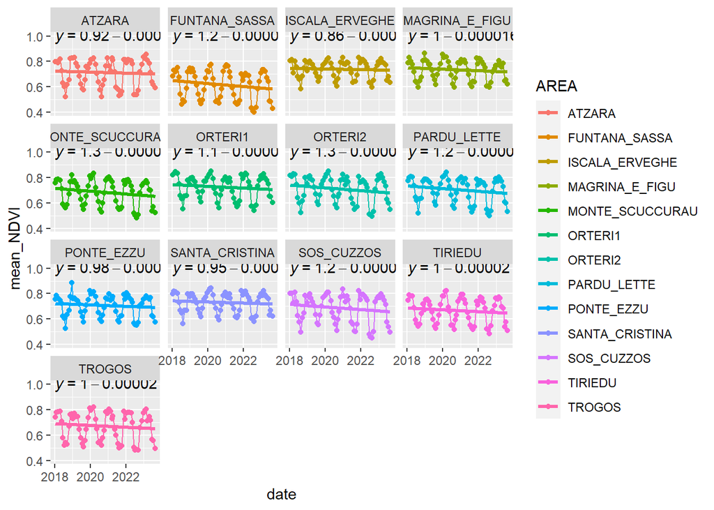

```r
# Crea un grafico separato per ogni area e visualizza l'equazione della retta di regressione
ggplot(data = ndvi_avg, aes(x = date, y = mean_NDVI, group = AREA)) +
  geom_line(aes(color=AREA)) +
  geom_point(aes(color=AREA)) +
  facet_wrap(~AREA) +
  geom_smooth(method = "lm", se = FALSE, linewidth = 1.2, aes(color=AREA)) +
  stat_regline_equation(label.y = 1, aes(label = ..eq.label..))
```

```r
# Ripulisci l'enviroment di R
rm(list=ls())
```

In questa sezione preparo il file con tutti i poligoni delle chiome

```r
shapefile_folder  <- "G:/Altri computer/Il_mio_computer/DOTTORATO/PROGETTI/OLIVASTRO_PAULILATINO/REGRESSIONE/VETTORIALI/crowns_areas"

shapefile_files <- list.files(shapefile_folder, pattern = ".shp$", full.names = TRUE)

# Read and combine all shapefiles
crowns0 <- lapply(shapefile_files, st_read)

# Modifica il nome della colonna CODice_ in COD
crowns0 <- lapply(crowns0, function(x) {
  names(x)[names(x) == "CODICE_"] <- "COD"
  return(x)
})

# Combina i dati
crowns <- bind_rows(crowns0)
st_crs(crowns) <- 32632

st_write(crowns, "G:/Altri computer/Il_mio_computer/DOTTORATO/PROGETTI/OLIVASTRO_PAULILATINO/REGRESSIONE/VETTORIALI/crowns_merged.shp", append = FALSE)
```

```r
# Ripulisci l'enviroment di R
rm(list=ls())
```

In questa sezione vado a lavorare sulle singole chiome degli alberi e non sui valori medi delle aree per ottenere come risultato finale un nuovo dataframe con il codice delle piante e il coefficiente angolare dell’equazione della tendenza dell’NDVI calcolata tramite una regressione lieneare.

```r
# Carica i pacchetti necessari
library(tidyverse)
library(sf)
library(dplyr)
```

```r
# Carica i file delle chiome e dei pixel estratti in formato shp
crowns <- st_read("G:/Altri computer/Il_mio_computer/DOTTORATO/PROGETTI/OLIVASTRO_PAULILATINO/REGRESSIONE/VETTORIALI/crowns_merged.shp", crs = 32632)

NDVI_VALUES <- st_read("G:/Altri computer/Il_mio_computer/DOTTORATO/PROGETTI/OLIVASTRO_PAULILATINO/REGRESSIONE/VETTORIALI/NDVI_VALUES/NDVI_VALUES.shp", crs = 32632)

# Step 1: Calcola la media di NDVI per ogni data e COD
ndvi_aggregated <- NDVI_VALUES %>%
  group_by(COD, date) %>%
  summarise(ndvi = mean(ndvi))

# Effettua il join in base alla colonna COD
joined_df <- crowns %>%
  st_join(ndvi_aggregated %>% dplyr::select(geometry, date, ndvi), by = "COD")

# Rimuovi le righe con valori NA
cleaned_df <- na.omit(joined_df)

# Filtra i dati in modo che ogni COD abbia esattamente 68 righe
filtered_df <- cleaned_df %>%
  group_by(COD) %>%
  slice(1:68)

# Salva l'oggetto sf combinato nel file shapefile
st_write(filtered_df, "G:/Altri computer/Il_mio_computer/DOTTORATO/PROGETTI/OLIVASTRO_PAULILATINO/REGRESSIONE/VETTORIALI/NDVI_VALUES/merged_data_ndvi.shp", append= FALSE)
```

```r
# Ripulisci l'enviroment di R
rm(list=ls())
```

```r
# Carica il nuovo file combinato
NDVI_VALUES <- st_read("G:/Altri computer/Il_mio_computer/DOTTORATO/PROGETTI/OLIVASTRO_PAULILATINO/REGRESSIONE/VETTORIALI/NDVI_VALUES/merged_data_ndvi.shp")

# Converti COD in un fattore (se non è già stato fatto)
NDVI_VALUES$COD <- as.factor(NDVI_VALUES$COD)

# Raggruppa per COD e calcola la regressione lineare per ciascun gruppo
pixel_trend <- NDVI_VALUES %>%
  group_by(COD) %>%
  summarise(coef = coef(lm(ndvi ~ date))[2])

# Approssima i coefficienti alla quinta cifra decimale senza notazione esponenziale
pixel_trend <- pixel_trend %>%
  mutate(
    coef = round(coef, 6)
  )

st_write(pixel_trend, "G:/Altri computer/Il_mio_computer/DOTTORATO/PROGETTI/OLIVASTRO_PAULILATINO/REGRESSIONE/VETTORIALI/NDVI_VALUES/pixels_trend.shp", append= FALSE)
```

```r
# Ripulisci l'enviroment di R
rm(list=ls())
```

In questa sezione si applica il procedimento eseguito da *Lambert et al., 2015* per stimare il trend delle serie temporali.

```r
library(sf)
library(dplyr)
library(lubridate)
library(DBEST)
library(progress)
library(trend)
library(mblm)
library(RobustLinearReg)
library(readr)
```

```r
# Carica il nuovo file combinato
NDVI_VALUES <- st_read("G:/Altri computer/Il_mio_computer/DOTTORATO/PROGETTI/OLIVASTRO_PAULILATINO/REGRESSIONE/VETTORIALI/NDVI_VALUES/merged_data_ndvi.shp")
```

```r
# Imposta l'opzione scipen su un valore elevato per eliminare la notazione esponenziale dei valori
options(scipen = 999)

# Ottieni l'elenco unico dei COD
cod_list <- unique(NDVI_VALUES$COD)

# Crea un dataframe vuoto per memorizzare i risultati
results_phenoloy <- data.frame()

# Crea una nuova barra di avanzamento
pb <- progress_bar$new(total = length(cod_list))

# Esegui il ciclo for su ogni COD
for (cod in cod_list) {
  # Seleziona i dati per il COD corrente
  data0 <- NDVI_VALUES[NDVI_VALUES$COD == cod, ]
  ts <- ts(data0$ndvi, start = c(2018, 1), end = c(2023, 8), frequency = 12)

  # calcola l'SOS
  phenology <- Phenology(ts, tsgf="TSGFspline", approach="White")
  # ottieni lo Start of Season and the End of Season per ogni albero
  sos <- phenology$sos
  eos <- phenology$eos

  # Converte la serie temporale in un dataframe
  sos_df <- as.data.frame(as.numeric(sos))
  eos_df <- as.data.frame(as.numeric(eos))

  # Aggiungi i risultati al dataframe
  results_phenoloy <- rbind(results_phenoloy, data.frame(COD = cod, SOS = sos_df, EOS = eos_df))

    # Aggiorna la barra di avanzamento solo se non ha raggiunto il limite
  if (!pb$finished) {
    pb$tick()
  }
}
```

```r
# Calcola la media e la deviazione standard per SOS
mean_sos <- mean(results_phenoloy$`as.numeric.sos.`, na.rm = TRUE)
sd_sos <- sd(results_phenoloy$`as.numeric.sos.`, na.rm = TRUE)

# Calcola la media e la deviazione standard per EOS
mean_eos <- mean(results_phenoloy$`as.numeric.eos.`, na.rm = TRUE)
sd_eos <- sd(results_phenoloy$`as.numeric.eos.`, na.rm = TRUE)

# Stampa i risultati
print(paste("Media SOS: ", mean_sos))
print(paste("Deviazione standard SOS: ", sd_sos))
print(paste("Media EOS: ", mean_eos))
print(paste("Deviazione standard EOS: ", sd_eos))

# Crea un nuovo dataframe con questi oggetti
summary_df_phenology <- data.frame(
  Mean_SOS = mean(results_phenoloy$`as.numeric.sos.`, na.rm = TRUE),
  SD_SOS = sd(results_phenoloy$`as.numeric.sos.`, na.rm = TRUE),
  Mean_EOS = mean(results_phenoloy$`as.numeric.eos.`, na.rm = TRUE),
  SD_EOS = sd(results_phenoloy$`as.numeric.eos.`, na.rm = TRUE)
)

# Aggiungi le date al dataframe
summary_df_phenology$Date_SOS <- as.Date(summary_df_phenology$Mean_SOS, origin = "2023-01-01")
summary_df_phenology$Date_EOS <- as.Date(summary_df_phenology$Mean_EOS, origin = "2023-01-01")

# Salvo il file con le classi
write_csv(summary_df_phenology, "G:/Altri computer/Il_mio_computer/DOTTORATO/PROGETTI/OLIVASTRO_PAULILATINO/REGRESSIONE/CSV/summary_df_phenology.csv", append = FALSE)
```

```r
# Ripulisci l'enviroment di R
rm(list=ls())
```

A seguito dell’analisi delle serie temporali, è stato individuato il mese di ottobre come SOS e il mesi di Maggio come EOS.

```r
read.csv("G:/Altri computer/Il_mio_computer/DOTTORATO/PROGETTI/OLIVASTRO_PAULILATINO/REGRESSIONE/CSV/summary_df_phenology.csv", header = TRUE)
```

```
##   Mean_SOS   SD_SOS Mean_EOS   SD_EOS   Date_SOS   Date_EOS
## 1 277.2482 18.70069 125.4083 11.83481 2023-10-05 2023-05-06
```

```r
# Ripulisci l'enviroment di R
rm(list=ls())
```

```r
# Carica il nuovo file combinato
NDVI_VALUES <- st_read("G:/Altri computer/Il_mio_computer/DOTTORATO/PROGETTI/OLIVASTRO_PAULILATINO/REGRESSIONE/VETTORIALI/NDVI_VALUES/merged_data_ndvi.shp")
```

```r
# Imposta l'opzione scipen su un valore elevato per eliminare la notazione esponenziale dei valori
options(scipen = 999)

# Ottieni l'elenco unico dei COD
cod_list <- unique(NDVI_VALUES$COD)

# Inizializza una lista per memorizzare i risultati
results_list <- list()

# Crea una nuova barra di avanzamento

pb <- progress_bar$new(total = length(cod_list))

# Esegui il ciclo for su ogni COD
for (cod in cod_list) {
  # Seleziona i dati per il COD corrente
  data0 <- NDVI_VALUES[NDVI_VALUES$COD == cod, ]

  ts <- ts(data0$ndvi, start = c(2018, 1), end = c(2023, 8), frequency = 12)
  fit <- lm(ndvi ~ date, data = data0)

  # Esegui il test non parametrico di Mann-Kendall (MK)
  mk_test <- smk.test(ts)

  pettitt_test <- pettitt.test(ts)

  valore_K <- unname(pettitt_test$estimate)

  # Converti le date in numeri (numero di giorni dalla data minima)
  data0$date_numeric <- as.numeric(data0$date - min(data0$date))

  # Calcola Theil-Sen's slope (Q) utilizzando la data numerica
  # theil_sen_fit <- mblm(ndvi ~ date_numeric, data = data0)

  theil_sen_fit <- theil_sen_regression(ndvi ~ date, data = data0)

  # Estrazione della pendenza e l'intercetta
  slope_mblm <- theil_sen_fit$coefficients[2]
  intercept_mblm <- theil_sen_fit$coefficients[1]

  eq_theil = paste0(" slope = ", round(slope_mblm, 8))

  # Estrai Q
  Q <- coef(theil_sen_fit)[2]

  # Estrai i coefficienti
  intercept <- coef(fit)[1]
  slope <- coef(fit)[2]

  area <- unique(data0$COD)

  # Equazione della linea di regressione
  eq = paste0(" slope = ", round(slope, 8))

  dbest_analysis <- DBEST::DBEST(data = ts, data.type = "cyclical", algorithm = "change detection", breakpoints.no= 10, first.level.shift= 0.1, second.level.shift=0.2, duration=12, distance.threshold="default", alpha=0.05, plot="off" )

  trend_dbest <- dbest_analysis$Fit

  trend_df <- as.data.frame(trend_dbest, row.names = FALSE)
  colnames(trend_df) <- "ndvi"

  trend_df$date <- data0$date

  min_date <- min(data0$date)
  max_date <- max(data0$date)

  # Imposta i margini del grafico
  par(mar = c(5, 4.5, 4, 1),  mfrow = c(1,1))

  # Crea il grafico di dispersione dei dati
  plot(data0$date, data0$ndvi, type = "p", xlab = "Date", ylab = "NDVI values", xlim = c(min_date, max_date))

  # Sovrapponi la linea retta basata sui coeficienti del modello di Theil-Sen
  abline(theil_sen_fit, col= "red")

  # Linea di tendenza 1 (colore blu)
  lines(smooth.spline(data0$date, data0$ndvi), col = "blue")

  # Linea di tendenza 2 (colore nero)
  lines(trend_df$date, trend_df$ndvi, type = "l", col = "black")

  # Aggiungi il titolo e il sottotitolo
  title(main = area)
  mtext(eq_theil, side = 3, line = 0.3)

  # Salva i risultati e il grafico nella lista
  results_list[[cod]] <- list(intercept_mblm = intercept_mblm, slope_mblm = slope_mblm, area = area, plot = recordPlot(), mk = mk_test, valore_K = valore_K )

  # Aggiorna la barra di avanzamento solo se non ha raggiunto il limite
  if (!pb$finished) {
    pb$tick()
  }
}


saveRDS(results_list, file = "G:/Altri computer/Il_mio_computer/DOTTORATO/PROGETTI/OLIVASTRO_PAULILATINO/REGRESSIONE/SCRIPT/TrendNdviPaulilatino/Risultati/results_list.rds")
```

```r
results_list <- readRDS("G:/Altri computer/Il_mio_computer/DOTTORATO/PROGETTI/OLIVASTRO_PAULILATINO/REGRESSIONE/SCRIPT/TrendNdviPaulilatino/Risultati/results_list.rds")

# Inizializza un data frame vuoto
results_df <- data.frame()

# Crea una nuova barra di avanzamento
pb <- progress_bar$new(total = length(results_list))

# Loop attraverso ogni elemento in results_list2
for(i in 1:length(results_list)) {
  # Estrai i valori di area, intercept e slope
  COD <- results_list[[i]]$area
  intercept <- results_list[[i]]$intercept
  slope <- results_list[[i]]$slope_mblm
  mk_p_value <- results_list[[i]]$mk$p.value
  k_value <- results_list[[i]]$valore_K

  # Crea un data frame temporaneo con questi valori
  temp_df <- data.frame(COD = COD, intercept = intercept, slope = slope, mk_p_value = mk_p_value)

  # Aggiungi il data frame temporaneo al nuovo database
  results_df <- rbind(results_df, temp_df)

  # Rimuovi i nomi delle righe
  rownames(results_df) <- NULL

 # Aggiorna la barra di avanzamento solo se non ha raggiunto il limite
  if (!pb$finished) {
    pb$tick()
  }
}

# Visualizza il nuovo database
print(results_df)

# Aggiungi una nuova colonna per la classe di tendenza
results_df <- results_df %>%
  mutate(Trend_Class = case_when(
    mk_p_value > 0.05 ~ 0,
    mk_p_value > 0.01 ~ 1,
    mk_p_value > 0.001 ~ 2,
    TRUE ~ 3
  ))

write_csv(results_df, "G:/Altri computer/Il_mio_computer/DOTTORATO/PROGETTI/OLIVASTRO_PAULILATINO/REGRESSIONE/CSV/results_df_class.csv")
```

```r
# Ripulisci l'enviroment di R
rm(list=ls())
```

In questa sezione perparo il dataframe per visualizzare interattivamente la tendenza delle singole chiome in una mappa.

```r
library(tidyverse)
library(leaflet)
library(sf)
library(quadcleanR)
```

```r
# Carico il file de
pixel_trend0 <- st_read("G:/Altri computer/Il_mio_computer/DOTTORATO/PROGETTI/OLIVASTRO_PAULILATINO/REGRESSIONE/VETTORIALI/NDVI_VALUES/pixels_trend.shp")

class <- read_csv("G:/Altri computer/Il_mio_computer/DOTTORATO/PROGETTI/OLIVASTRO_PAULILATINO/REGRESSIONE/CSV/results_df_class.csv", col_names = T)

# Unisci i due data frames
merged_data <- merge(pixel_trend0, class, by = "COD")

# Transform to WGS84
pixel_trend_wgs84 <- st_transform(merged_data, crs = 4326)

pixel_trend_wgs84$coef <- format(pixel_trend_wgs84$coef, scientific = FALSE)

# Converti la colonna "coef" in un vettore numerico
pixel_trend_wgs84$coef <- as.numeric(pixel_trend_wgs84$coef)

pixel_trend <- pixel_trend_wgs84
```

```r
# Definizione della funzione di classificazione
classify_trend <- function(Trend_Class) {
  if (Trend_Class == 0) {
    return("Positive trends or trends not significantly different from the null slope")
  } else if (Trend_Class== 1) {
    return("Trends significantly negative, 0.05 > p-value > 0.01")
  } else if (Trend_Class == 2) {
    return("Trends significantly negative, 0.01 > p-value > 0.001")
  } else if (Trend_Class == 3) {
    return("Trends significantly negative, 0.001 > p-value")
  }
}

# Applicazione della funzione al dataframe
pixel_trend$Trend_Description <- sapply(pixel_trend$Trend_Class, classify_trend)

# Salvo il file con le classi
st_write(pixel_trend, "G:/Altri computer/Il_mio_computer/DOTTORATO/PROGETTI/OLIVASTRO_PAULILATINO/REGRESSIONE/VETTORIALI/NDVI_VALUES/pixels_trend3.shp", append = FALSE)
```

```r
# # Define the breaks for the categories
# breaks <- quantile(pixel_trend_wgs84$coef, probs = seq(0, 1, length.out = 5))
#
# # Aggiungi una nuova colonna "classe_trend" con le etichette delle classi
# pixel_trend <- pixel_trend %>%
#   mutate(classe_trend = case_when(
#     coef < breaks[[1]] + 0.000009 ~ "Decrescente Marcato",
#     coef >= breaks[[1]] + 0.000009 & coef <= breaks[[2]] ~ "Decrescente Moderato",
#     coef > breaks[[2]] & coef < breaks[[3]] + 0.000016 ~ "Decrescente Lieve",
#     coef >= breaks[[3]] + 0.000016 & coef <= breaks[[4]] + 0.000012 ~ "Stazionario",
#     coef > breaks[[4]] + 0.000011 ~ "Crescente"
#   ))
#
# # Salvo il file con le classi
# st_write(pixel_trend, "G:/Altri computer/Il_mio_computer/DOTTORATO/PROGETTI/OLIVASTRO_PAULILATINO/REGRESSIONE/VETTORIALI/NDVI_VALUES/pixels_trend2.shp", append = FALSE)
```

```r
# Ripulisci l'enviroment di R
rm(list=ls())
```

```r
# Carico il file merged_df per inserire nella mappa i punti campionati
sample_32632 <- st_read("G:/Altri computer/Il_mio_computer/DOTTORATO/PROGETTI/OLIVASTRO_PAULILATINO/VETTORIALI/DB_sample_vector.shp")

# Assign the CRS of ex_sf to points
sample_wgs84 <- st_transform(sample_32632, crs = 4326)

# Extract the coordinates using st_coordinates
coords <- st_coordinates(sample_wgs84$geometry)

# Add the latitude and longitude columns to the merged_sf dataframe
sample_wgs84$lat <- coords[, 2]
sample_wgs84$long <- coords[, 1]

st_write(sample_wgs84, "G:/Altri computer/Il_mio_computer/DOTTORATO/PROGETTI/OLIVASTRO_PAULILATINO/REGRESSIONE/VETTORIALI/sample_points.shp", append = FALSE )
```

```r
# Ripulisci l'enviroment di R
rm(list=ls())
```

```r
lim_paul_32632 <- st_read("G:/Altri computer/Il_mio_computer/DOTTORATO/PROGETTI/OLIVASTRO_PAULILATINO/VETTORIALI/Limite_Amministrativo_Paulilatino_EPSG-32632.shp")

# Assign the CRS of ex_sf to points
lim_paul_wgs84 <- st_transform(lim_paul_32632, crs = 4326)

st_write(lim_paul_wgs84, "G:/Altri computer/Il_mio_computer/DOTTORATO/PROGETTI/OLIVASTRO_PAULILATINO/VETTORIALI/Limite_Amministrativo_Paulilatino_wgs84.shp", append = FALSE )
```

```r
focolai0 <- st_read("G:/Altri computer/Il_mio_computer/DOTTORATO/PROGETTI/OLIVASTRO_PAULILATINO/REGRESSIONE/VETTORIALI/FOCOLAI.shp")

focolai <- st_transform(focolai0, crs = 4326)

st_write(focolai, "G:/Altri computer/Il_mio_computer/DOTTORATO/PROGETTI/OLIVASTRO_PAULILATINO/REGRESSIONE/VETTORIALI/FOCOLAI_wgs84.shp", append = FALSE )
```

```r
plots <- st_read("G:/Altri computer/Il_mio_computer/DOTTORATO/PROGETTI/OLIVASTRO_PAULILATINO/REGRESSIONE/VETTORIALI/BUFFER_ANALISI_NDVI.shp")

# Assign the CRS of ex_sf to points
plots <- st_transform(plots, crs = 4326)

st_write(plots, "G:/Altri computer/Il_mio_computer/DOTTORATO/PROGETTI/OLIVASTRO_PAULILATINO/REGRESSIONE/VETTORIALI/BUFFER_ANALISI_NDVI_WGS84.shp", append = TRUE)
```

```r
# Ripulisci l'enviroment di R
rm(list=ls())
```

In questo chunk cerco di creare una serie temproale di NDVI per ogni albero

```r
# # Carica il nuovo file combinato
# NDVI_VALUES <- st_read("G:/Altri computer/Il_mio_computer/DOTTORATO/PROGETTI/OLIVASTRO_PAULILATINO/REGRESSIONE/VETTORIALI/NDVI_VALUES/merged_data_ndvi.shp")
#
# # Eseguire il codice per ogni valore unico di COD
# unique_cod <- unique(NDVI_VALUES$COD)
#
# # Creare una funzione per applicare il codice a un valore specifico di COD
# applyCodeToCOD <- function(cod) {
#   subset_data <- NDVI_VALUES[NDVI_VALUES$COD == cod, ]
#
#   # Calcolare la serie temporale e applicare il filtro
#   ts <- ts(subset_data$ndvi, start = c(2018, 1), end = c(2023, 8), frequency = 12)
#   ts13 <- stats::filter(ts, rep(1, 12) / 12)
#
#   # Creare un grafico per il valore specifico di COD
#   plot(ts, type = "p")
#   lines(ts13, lwd = 2, col = "red")
# }
#
# # Applicare la funzione a ciascun valore unico di COD
# sapply(unique_cod, applyCodeToCOD)
```

```r
# Ripulisci l'enviroment di R
rm(list=ls())
```

```r
# Carica le librerie necessarielibrary(leaflet)
library(dplyr)
library(leaflet.extras)
library(leaflet)
library(sf)

# Imposta l'opzione scipen su un valore elevato per eliminare la notazione esponenziale dei valori
options(scipen = 999)

# Carico il nuovo file con le classi
pixel_trend <- st_read("G:/Altri computer/Il_mio_computer/DOTTORATO/PROGETTI/OLIVASTRO_PAULILATINO/REGRESSIONE/VETTORIALI/NDVI_VALUES/pixels_trend3.shp")
# Carico il file della geolocalizzazione dei campioni
samples <- st_read("G:/Altri computer/Il_mio_computer/DOTTORATO/PROGETTI/OLIVASTRO_PAULILATINO/REGRESSIONE/VETTORIALI/sample_points.shp")
lim_paul_wgs84 <- st_read("G:/Altri computer/Il_mio_computer/DOTTORATO/PROGETTI/OLIVASTRO_PAULILATINO/VETTORIALI/Limite_Amministrativo_Paulilatino_wgs84.shp")
focolai_wgs84 <- st_read("G:/Altri computer/Il_mio_computer/DOTTORATO/PROGETTI/OLIVASTRO_PAULILATINO/REGRESSIONE/VETTORIALI/FOCOLAI_wgs84.shp")
```

```r
plots_wgs84 <- st_read("G:/Altri computer/Il_mio_computer/DOTTORATO/PROGETTI/OLIVASTRO_PAULILATINO/REGRESSIONE/VETTORIALI/BUFFER_ANALISI_NDVI_WGS84.shp")
# Define a custom color palette for classes
class_palette <- c("p-value > 0.05" = "#00ff00",  # Green
                   "0.05 > p-value > 0.01" = "yellow",  # Yellow-green
                   "0.01 > p-value > 0.001" = "orange",
                   "0.001 > p-value" = "red")

# Create a color factor with the custom palette and class labels
color_factor1 <- leaflet::colorFactor(palette = class_palette, levels = c("0", "1", "2", "3"))

color_factor2 <- leaflet::colorFactor(palette = class_palette, levels = c("Positive trends or trends not significantly different from the null slope", "Trends significantly negative, 0.05 > p-value > 0.01", "Trends significantly negative, 0.01 > p-value > 0.001", "Trends significantly negative, 0.001 > p-value"))

# Definisci l'ordine desiderato delle etichette delle classi
custom_order <- c("0", "1", "2", "3")

# Make sure 'Trnd_Ds' is a factor with the defined order
pixel_trend$Trnd_Cl  <- factor(pixel_trend$Trnd_Cl , levels = custom_order)

# Crea una funzione di colorazione per i cerchi
color_factor_circle <- colorFactor(
  palette = c("green", "red"),
  domain = c("+", "-")
)

# Crea la mappa Leaflet
map <- leaflet(options = leafletOptions(maxZoom = 22)) %>%
  addProviderTiles("Esri.WorldImagery", group = "Imagery", options = providerTileOptions()) %>%
  addPolygons(data = lim_paul_wgs84,
              fillOpacity = 0,
              color = "black",
              weight = 2,
              group = 'Lim. Amm. Paulilatino'  # Add a group name
  ) %>%
  addPolygons(data = focolai_wgs84,
              fillOpacity = 0,
              color = "red",
              weight = 2,
              group = 'Outbreaks'
  ) %>%
  addPolygons(data = plots_wgs84,
              fillOpacity = 0,
              color = "yellow",
              weight = 2,
              group = 'plots'
  ) %>%
  addCircleMarkers(data = samples,
                   lng = ~long,
                   lat = ~lat,
                   fillColor = ~color_factor_circle(samples$positivo),
                   fillOpacity = 0.6,
                   popup = ~paste("AREA:", location, "<br/>CAMPIONE:", id_sample, "<br/>SINTOMATICO:", sin_asin, "<br/>POSITIVITÀ:", positivo),
                   radius = 3,
                   group = 'samples',
                   stroke = FALSE
  ) %>%
  addLegend(pal = color_factor_circle,
            values = samples$positivo,
            title = "Sample Positivity",
            opacity = 0.6,
            position = "bottomright"
  )

# Aggiungi i poligoni con colorazione basata sulla pendenza
map <- map %>%
  addPolygons(data = pixel_trend,
              fillColor = ~ifelse(slope > 0, "#00ff00", color_factor1(Trnd_Cl)),
              color = "black",
              fillOpacity = 0.6,
              highlightOptions = highlightOptions(color = "white", weight = 2, bringToFront = TRUE),
              popup = ~paste("COD:", COD, "<br/>slope:", slope, "<br/>class:", Trnd_Cl, "<br/>Description:", Trnd_Ds),
              group = 'Crowns',
              stroke = TRUE,
              weight = 1
  ) %>%
  addLegend(title = "Trend: lm(NDVI ~ Month)",
            pal = color_factor2,
            values = pixel_trend$Trnd_Ds,
            opacity = 0.6,
            position = "topright"
  ) %>%
  addFullscreenControl() %>%
  addLayersControl(
    overlayGroups = c("Crowns", "samples", "Lim. Amm. Paulilatino", "Outbreaks","plots"),    # Add the new group
    options = layersControlOptions(collapsed = TRUE)
  )

# Visualizza la mappa
map
```

[interactive chart not shown]

```r
library(htmlwidgets)

# Salva la mappa
saveWidget(map, file = "G:/Altri computer/Il_mio_computer/DOTTORATO/PROGETTI/OLIVASTRO_PAULILATINO/REGRESSIONE/map4.html", selfcontained = FALSE)
```

```r
# Ripulisci l'enviroment di R
rm(list=ls())
```